# R coding Exercise

#First, load the “dslabs” package (install if needed). Also, load any other packages needed.

```r
library("dslabs")
library("tidyverse")
library(dplyr)
```

#Look at help file for gapminder data.

```r
help("gapminder")
```

```
## starting httpd help server ... done
```

```r
str("gapminder")
```

```
##  chr "gapminder"
```

```r
summary("gapminder")
```

```
##    Length     Class      Mode
##         1 character character
```

```r
class("gapminder")
```

```
## [1] "character"
```

#Assigns only the African countries to a new object/variable called “africadata”.

```r
africadata <- gapminder %>%
dplyr::filter(continent == "Africa")
```

#Check to see if you did it correclty (should have 2907 observations)

```r
str(africadata)
```

```
## 'data.frame':    2907 obs. of  9 variables:
##  $ country         : Factor w/ 185 levels "Albania","Algeria",..: 2 3 18 22 26 27 29 31 32 33 ...
##  $ year            : int  1960 1960 1960 1960 1960 1960 1960 1960 1960 1960 ...
##  $ infant_mortality: num  148 208 187 116 161 ...
##  $ life_expectancy : num  47.5 36 38.3 50.3 35.2 ...
##  $ fertility       : num  7.65 7.32 6.28 6.62 6.29 6.95 5.65 6.89 5.84 6.25 ...
##  $ population      : num  11124892 5270844 2431620 524029 4829291 ...
##  $ gdp             : num  1.38e+10 NA 6.22e+08 1.24e+08 5.97e+08 ...
##  $ continent       : Factor w/ 5 levels "Africa","Americas",..: 1 1 1 1 1 1 1 1 1 1 ...
##  $ region          : Factor w/ 22 levels "Australia and New Zealand",..: 11 10 20 17 20 5 10 20 10 10 ...
```

```r
summary(africadata)
```

```
##          country          year      infant_mortality life_expectancy
##  Algeria     :  57   Min.   :1960   Min.   : 11.40   Min.   :13.20
##  Angola      :  57   1st Qu.:1974   1st Qu.: 62.20   1st Qu.:48.23
##  Benin       :  57   Median :1988   Median : 93.40   Median :53.98
##  Botswana    :  57   Mean   :1988   Mean   : 95.12   Mean   :54.38
##  Burkina Faso:  57   3rd Qu.:2002   3rd Qu.:124.70   3rd Qu.:60.10
##  Burundi     :  57   Max.   :2016   Max.   :237.40   Max.   :77.60
##  (Other)     :2565                  NA's   :226
##    fertility       population             gdp               continent
##  Min.   :1.500   Min.   :    41538   Min.   :4.659e+07   Africa  :2907
##  1st Qu.:5.160   1st Qu.:  1605232   1st Qu.:8.373e+08   Americas:   0
##  Median :6.160   Median :  5570982   Median :2.448e+09   Asia    :   0
##  Mean   :5.851   Mean   : 12235961   Mean   :9.346e+09   Europe  :   0
##  3rd Qu.:6.860   3rd Qu.: 13888152   3rd Qu.:6.552e+09   Oceania :   0
##  Max.   :8.450   Max.   :182201962   Max.   :1.935e+11
##  NA's   :51      NA's   :51          NA's   :637
##                        region
##  Eastern Africa           :912
##  Western Africa           :912
##  Middle Africa            :456
##  Northern Africa          :342
##  Southern Africa          :285
##  Australia and New Zealand:  0
##  (Other)                  :  0
```

#Create new object with the Life expectancy and infant mortality of African Countries.

```r
africa_life_infant <- africadata %>%
  select("country", "life_expectancy", "infant_mortality")
```

#Create new object with the Life expectancy and population of African Countries.

```r
africa_life_pop <- africadata %>%
  select("country", "life_expectancy", "population")
```

#Plot life expectancy as a function of infant mortality.

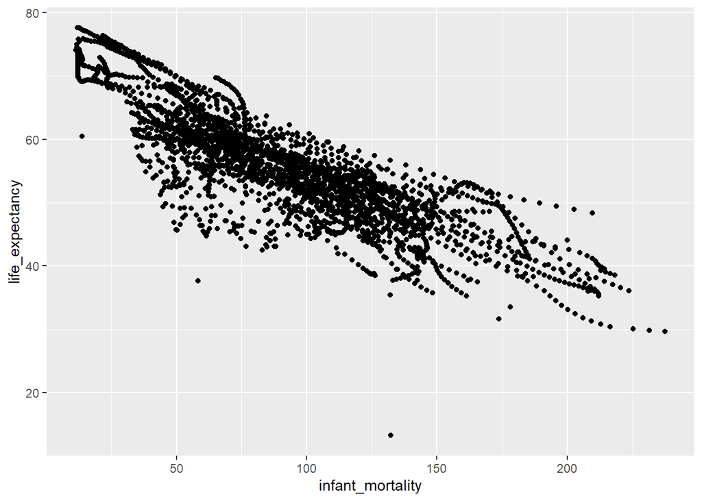

```r
ggplot(data = africa_life_infant) +
  geom_point(mapping = aes(infant_mortality, life_expectancy))
```

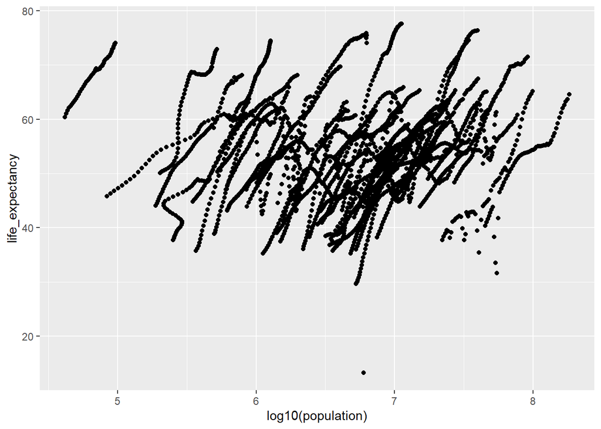

```r
ggplot(data = africa_life_pop) +
  geom_point(mapping = aes(log10(population), life_expectancy))
```

```r
Missing1 <- africadata %>%
           select(year,infant_mortality) %>%
           filter(is.na(infant_mortality)) %>%
           count(year) %>%
           arrange(-n)
```

#Select data from Y2K

```r
Y2K_africadata <- africadata %>%
  filter(year == "2000")
```

#Create new object with the Life expectancy and infant mortality of African Countries for Y2K.

```r
Y2K_africa_life_infant <- Y2K_africadata %>%
  select("country", "life_expectancy", "infant_mortality")
```

#Create new object with the Life expectancy and population of African Countries.

```r
Y2K_africa_life_pop <- Y2K_africadata %>%
  select("country", "life_expectancy", "population")
```

#Plot life expectancy as a function of infant mortality.

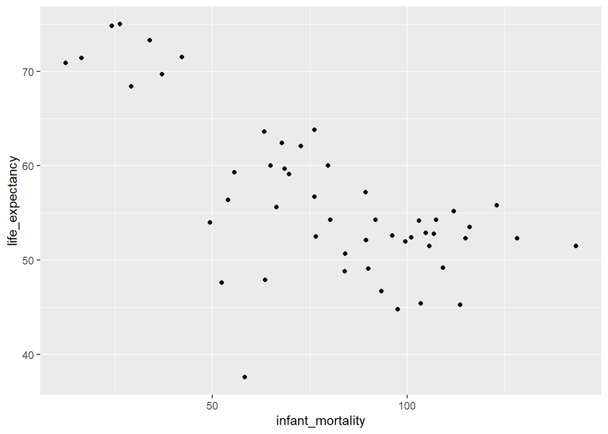

```r
ggplot(data = Y2K_africa_life_infant) +
  geom_point(mapping = aes(infant_mortality, life_expectancy))
```

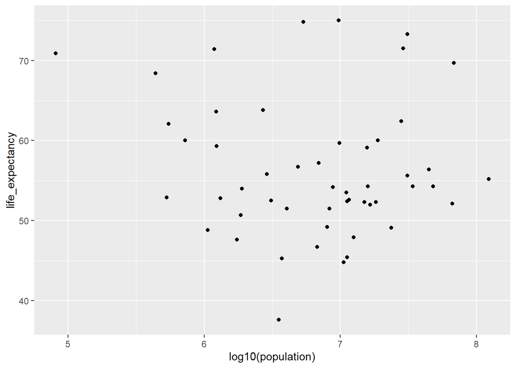

```r
ggplot(data = Y2K_africa_life_pop) +
  geom_point(mapping = aes(log10(population), life_expectancy))
```

#Linear Model: Infant Mortality, Life Expectancy for Y2K.

```r
fit_infant_life <- lm(life_expectancy~infant_mortality, data = Y2K_africa_life_infant)
summary(fit_infant_life)
```

```
##
## Call:
## lm(formula = life_expectancy ~ infant_mortality, data = Y2K_africa_life_infant)
##
## Residuals:
##      Min       1Q   Median       3Q      Max
## -22.6651  -3.7087   0.9914   4.0408   8.6817
##
## Coefficients:
##                  Estimate Std. Error t value Pr(>|t|)
## (Intercept)      71.29331    2.42611  29.386  < 2e-16 ***
## infant_mortality -0.18916    0.02869  -6.594 2.83e-08 ***
## ---
## Signif. codes:  0 '***' 0.001 '**' 0.01 '*' 0.05 '.' 0.1 ' ' 1
##
## Residual standard error: 6.221 on 49 degrees of freedom
## Multiple R-squared:  0.4701, Adjusted R-squared:  0.4593
## F-statistic: 43.48 on 1 and 49 DF,  p-value: 2.826e-08
```

#p-value = 2.826e-08; Based on the p-value, there is a significant correlation between infant mortality and life expectancy. As such, the slope of the relationship is negative, indicating a significant negative relationship between infant mortlaity and life expectancy. As infant mortality increases, life expectancy decreases.

#Linear Model: population, Life Expectancy for Y2K.

```r
fit_pop_life <- lm(life_expectancy~population, data = Y2K_africa_life_pop)
summary(fit_pop_life)
```

```
##
## Call:
## lm(formula = life_expectancy ~ population, data = Y2K_africa_life_pop)
##
## Residuals:
##     Min      1Q  Median      3Q     Max
## -18.429  -4.602  -2.568   3.800  18.802
##
## Coefficients:
##              Estimate Std. Error t value Pr(>|t|)
## (Intercept) 5.593e+01  1.468e+00  38.097   <2e-16 ***
## population  2.756e-08  5.459e-08   0.505    0.616
## ---
## Signif. codes:  0 '***' 0.001 '**' 0.01 '*' 0.05 '.' 0.1 ' ' 1
##
## Residual standard error: 8.524 on 49 degrees of freedom
## Multiple R-squared:  0.005176,   Adjusted R-squared:  -0.01513
## F-statistic: 0.2549 on 1 and 49 DF,  p-value: 0.6159
```

#P-value = 0.6159; Based on the p-value, no significant relationship between population size and life expectancy exists.

2021.09.09: Additions by MYC